# Naive Bayes

#Flights at ABIA

```
##  [1] "Year"              "Month"             "DayofMonth"
##  [4] "DayOfWeek"         "DepTime"           "CRSDepTime"
##  [7] "ArrTime"           "CRSArrTime"        "UniqueCarrier"
## [10] "FlightNum"         "TailNum"           "ActualElapsedTime"
## [13] "CRSElapsedTime"    "AirTime"           "ArrDelay"
## [16] "DepDelay"          "Origin"            "Dest"
## [19] "Distance"          "TaxiIn"            "TaxiOut"
## [22] "Cancelled"         "CancellationCode"  "Diverted"
## [25] "CarrierDelay"      "WeatherDelay"      "NASDelay"
## [28] "SecurityDelay"     "LateAircraftDelay"
```

```
##  [1] "Year"              "Month"             "DayofMonth"
##  [4] "DayOfWeek"         "DepTime"           "CRSDepTime"
##  [7] "ArrTime"           "CRSArrTime"        "UniqueCarrier"
## [10] "FlightNum"         "TailNum"           "ActualElapsedTime"
## [13] "CRSElapsedTime"    "AirTime"           "ArrDelay"
## [16] "DepDelay"          "Origin"            "Dest"
## [19] "Distance"          "TaxiIn"            "TaxiOut"
## [22] "Cancelled"         "CancellationCode"  "Diverted"
## [25] "CarrierDelay"      "WeatherDelay"      "NASDelay"
## [28] "SecurityDelay"     "LateAircraftDelay" "Austin"
```

```
## [1] "Month"     "Cancelled" "Austin"
```

```
## [1] "Month"     "Cancelled" "Austin"
```

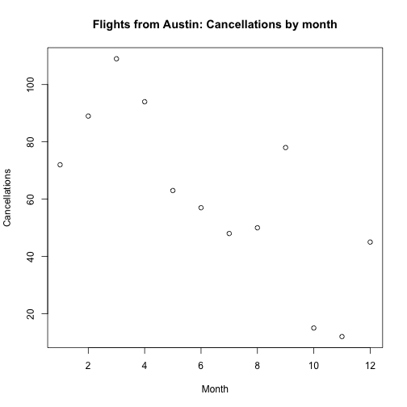

- March had the most flights cancelled.

```
##  [1] "Year"              "Month"             "DayofMonth"
##  [4] "DayOfWeek"         "DepTime"           "CRSDepTime"
##  [7] "ArrTime"           "CRSArrTime"        "UniqueCarrier"
## [10] "FlightNum"         "TailNum"           "ActualElapsedTime"
## [13] "CRSElapsedTime"    "AirTime"           "ArrDelay"
## [16] "DepDelay"          "Origin"            "Dest"
## [19] "Distance"          "TaxiIn"            "TaxiOut"
## [22] "Cancelled"         "CancellationCode"  "Diverted"
## [25] "CarrierDelay"      "WeatherDelay"      "NASDelay"
## [28] "SecurityDelay"     "LateAircraftDelay" "Austin"
```

```
## [1] "Dest"      "Cancelled" "Austin"
```

```
##  [1]  435 2252  792  368  730  380  659  653 5573 2673 5506    1    1 1349
## [15]  949  481 2319  367  670 3691  218  226 1358 1231 1733  692  245  470
## [29]  459  632  712  834   55  444  236   88  305 2514    1  290 2783  231
## [43]  719  149  610  968  548  245   95  367   88  228
```

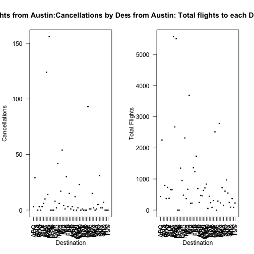

- This shows the number of cancellations of flights from Austin to various airports. Dallas has by far the most cancellations, however it also had the most flights.

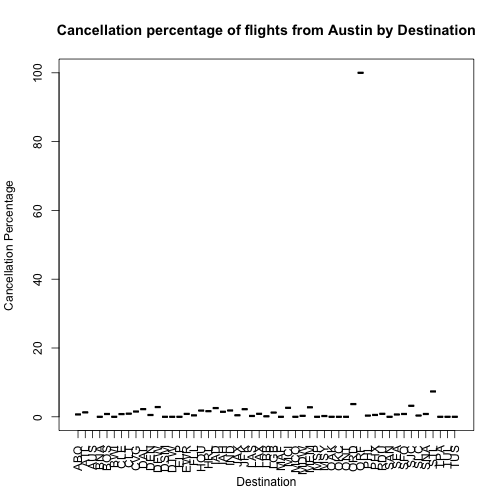

- This shows the percent of flights to each destination that are cancelled.

```
## [1] "DayOfWeek" "Cancelled" "Austin"
```

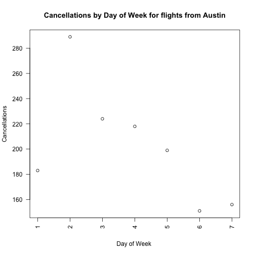

- This shows the total cancellations by day of the week on flights from Austin. Tuesday had the most cancellations by roughly 70 cancellations over the course of the year.

```
##  [1] "Year"              "Month"             "DayofMonth"
##  [4] "DayOfWeek"         "DepTime"           "CRSDepTime"
##  [7] "ArrTime"           "CRSArrTime"        "UniqueCarrier"
## [10] "FlightNum"         "TailNum"           "ActualElapsedTime"
## [13] "CRSElapsedTime"    "AirTime"           "ArrDelay"
## [16] "DepDelay"          "Origin"            "Dest"
## [19] "Distance"          "TaxiIn"            "TaxiOut"
## [22] "Cancelled"         "CancellationCode"  "Diverted"
## [25] "CarrierDelay"      "WeatherDelay"      "NASDelay"
## [28] "SecurityDelay"     "LateAircraftDelay" "Austin"
```

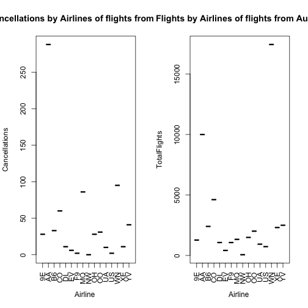

- This shows cancellations on flights from Austin by airline next to the total number of flights from Austin by each airline in 2008.

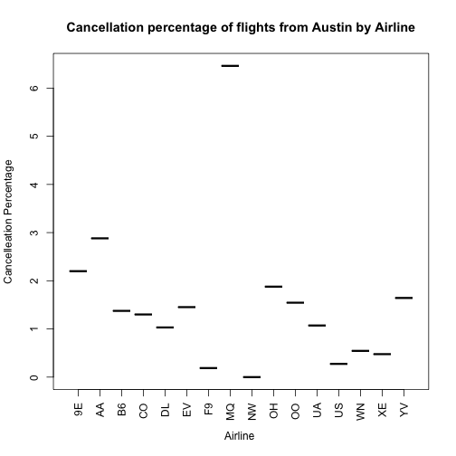

- This shows the percent of flights cancelled by airline for flights from Austin. While American airlines cancelled the most flights in 2008, American Eagle cancelled the largest percentage of its flights.

#Author Attribution

- I used Naive Bayes and Random Forest to try to determine the authors of each article.

```r
library(tm)
```

```r
library(e1071)
library(rpart)
library(ggplot2)
library(caret)

#reader function
readerPlain = function(fname){
  readPlain(elem=list(content=readLines(fname)), id=fname, language='en') }
```

##Training Corpus

```r
author_dirs = Sys.glob('./ReutersC50/C50train/*')
file_list = NULL
train_labels = NULL
for(author in author_dirs) {
  author_name = substring(author, first=23)
  files_to_add = Sys.glob(paste0(author, '/*.txt'))
  file_list = append(file_list, files_to_add)
  train_labels = append(train_labels, rep(author_name, length(files_to_add)))
}

all_docs = lapply(file_list, readerPlain)
names(all_docs) = file_list
names(all_docs) = sub('.txt', '', names(all_docs))


train_corpus = Corpus(VectorSource(all_docs))
names(train_corpus) = file_list


train_corpus = tm_map(train_corpus, content_transformer(tolower))
train_corpus = tm_map(train_corpus, content_transformer(removeNumbers))
train_corpus = tm_map(train_corpus, content_transformer(removePunctuation))
train_corpus = tm_map(train_corpus, content_transformer(stripWhitespace))
train_corpus = tm_map(train_corpus, content_transformer(removeWords), stopwords("SMART"))
```

- Here I'm putting the training articles into one corpus and cleaning/ tokenizing similarly to the example in class.
- Next comes making a data matrix and removing sparse terms.

```r
DTM_train = DocumentTermMatrix(train_corpus)
DTM_train = removeSparseTerms(DTM_train, 0.95)
```

##Testing Corpus

```r
author_dirs = Sys.glob('./ReutersC50/C50test/*')
file_list = NULL
test_labels = NULL
for(author in author_dirs) {
  author_name = substring(author, first=22)
  files_to_add = Sys.glob(paste0(author, '/*.txt'))
  file_list = append(file_list, files_to_add)
  test_labels = append(test_labels, rep(author_name, length(files_to_add)))
}


all_docs = lapply(file_list, readerPlain)
names(all_docs) = file_list
names(all_docs) = sub('.txt', '', names(all_docs))


test_corpus = Corpus(VectorSource(all_docs))
names(test_corpus) = file_list

test_corpus = tm_map(test_corpus, content_transformer(tolower))
test_corpus = tm_map(test_corpus, content_transformer(removeNumbers))
test_corpus = tm_map(test_corpus, content_transformer(removePunctuation))
test_corpus = tm_map(test_corpus, content_transformer(stripWhitespace))
test_corpus = tm_map(test_corpus, content_transformer(removeWords), stopwords("SMART"))
```

- The process for creating the testing corpus is similar to the training corpus to this point.

```r
reuters_dict = dimnames(DTM_train)[[2]]


DTM_test = DocumentTermMatrix(test_corpus, list(dictionary=reuters_dict))
DTM_test = removeSparseTerms(DTM_test, 0.95)


DTM_train_df = as.data.frame(inspect(DTM_train))
```

[output not shown]

[output cut: 6463 more lines]

[output not shown]

```r
DTM_test_df = as.data.frame(inspect(DTM_test))
```

[output not shown]

[output cut: 5838 more lines]

[output not shown]

- This helps deal with words that were not seen in data set by just focusing on the 641 words that made it from the training data and sparsity.

### Naive Bayes

```r
model_NB = naiveBayes(x=DTM_train_df, y=as.factor(train_labels), laplace=2)

pred_NB = predict(model_NB, DTM_test_df)


table_NB = as.data.frame(table(pred_NB,test_labels))


conf_NB = confusionMatrix(table(pred_NB,test_labels))

conf_NB_df = as.data.frame(conf_NB$byClass)
conf_NB_df[order(-conf_NB_df$Sensitivity),c(1,2,8)]
```

```
##                          Sensitivity Specificity Balanced Accuracy
## Class: PeterHumphrey            0.94   0.8506122         0.8953061
## Class: RogerFillion             0.86   0.9081633         0.8840816
## Class: KouroshKarimkhany        0.76   0.9583673         0.8591837
## Class: LydiaZajc                0.74   0.9706122         0.8553061
## Class: JimGilchrist             0.68   0.9967347         0.8383673
## Class: AlanCrosby               0.66   0.9167347         0.7883673
## Class: LynneO'Donnell           0.66   0.9926531         0.8263265
## Class: RobinSidel               0.66   0.9832653         0.8216327
## Class: MatthewBunce             0.62   0.9963265         0.8081633
## Class: AaronPressman            0.60   0.9640816         0.7820408
## Class: JoWinterbottom           0.48   0.9906122         0.7353061
## Class: BenjaminKangLim          0.44   0.9579592         0.6989796
## Class: TimFarrand               0.44   0.9832653         0.7116327
## Class: FumikoFujisaki           0.42   0.9983673         0.7091837
## Class: TheresePoletti           0.36   0.9800000         0.6700000
## Class: DavidLawder              0.34   0.9012245         0.6206122
## Class: SimonCowell              0.32   0.9914286         0.6557143
## Class: PierreTran               0.30   0.9991837         0.6495918
## Class: BernardHickey            0.28   0.9975510         0.6387755
## Class: KevinMorrison            0.26   0.9991837         0.6295918
## Class: LynnleyBrowning          0.26   0.9995918         0.6297959
## Class: JohnMastrini             0.24   0.9926531         0.6163265
## Class: JonathanBirt             0.24   0.9934694         0.6167347
## Class: KarlPenhaul              0.24   0.9987755         0.6193878
## Class: EricAuchard              0.22   0.9979592         0.6089796
## Class: GrahamEarnshaw           0.22   0.9983673         0.6091837
## Class: KeithWeir                0.20   0.9967347         0.5983673
## Class: MarcelMichelson          0.20   0.9975510         0.5987755
## Class: NickLouth                0.18   0.9967347         0.5883673
## Class: JanLopatka               0.12   0.9840816         0.5520408
## Class: MartinWolk               0.12   0.9971429         0.5585714
## Class: AlexanderSmith           0.10   0.9991837         0.5495918
## Class: HeatherScoffield         0.10   0.9893878         0.5446939
## Class: KirstinRidley            0.10   1.0000000         0.5500000
## Class: BradDorfman              0.08   0.9975510         0.5387755
## Class: JoeOrtiz                 0.08   0.9975510         0.5387755
## Class: KevinDrawbaugh           0.08   1.0000000         0.5400000
## Class: ToddNissen               0.08   0.9983673         0.5391837
## Class: MichaelConnor            0.06   0.9991837         0.5295918
## Class: SarahDavison             0.06   0.9991837         0.5295918
## Class: EdnaFernandes            0.04   1.0000000         0.5200000
## Class: PatriciaCommins          0.04   0.9991837         0.5195918
## Class: SamuelPerry              0.04   0.9991837         0.5195918
## Class: ScottHillis              0.04   0.9995918         0.5197959
## Class: MarkBendeich             0.02   1.0000000         0.5100000
## Class: DarrenSchuettler         0.00   0.9995918         0.4997959
## Class: JaneMacartney            0.00   0.9995918         0.4997959
## Class: MureDickie               0.00   0.9983673         0.4991837
## Class: TanEeLyn                 0.00   0.9995918         0.4997959
## Class: WilliamKazer             0.00   1.0000000         0.5000000
```

- This creates runs the Naive Bayes' model and creates a confusion matrix of results. This model has an accuracy score of 27.96%. Authors such as Peter Humphrey and Roger Fillion were predicted fairly accurately while the model failed to predict Schuettler, Macartney,Dicke,Eelyn and Kazer.

### Random Forest

- This method makes sense since it allows for many simulations of different combinations of words to try to predict the author.

```r
set.seed(1)
DTM_test = as.matrix(DTM_test)
DTM_train = as.matrix(DTM_train)

xx <- data.frame(DTM_test[,intersect(colnames(DTM_test), colnames(DTM_train))])
yy <- read.table(textConnection(""), col.names = colnames(DTM_train), colClasses = "integer")
```

- This makes sure that both the test set has all of the same words as the training set.

```r
library(plyr)
DTM_test_clean = rbind.fill(xx, yy)

DTM_test_df = as.data.frame(DTM_test_clean)

library(randomForest)
model_RF = randomForest(x=DTM_train_df, y=as.factor(train_labels), mtry=4, ntree=350)
pred_RF = predict(model_RF, data=DTM_test_clean)

table_RF = as.data.frame(table(pred_RF,test_labels))


conf_RF = confusionMatrix(table(pred_RF,test_labels))

conf_RF$overall
```

```
##       Accuracy          Kappa  AccuracyLower  AccuracyUpper   AccuracyNull
##      0.7404000      0.7351020      0.7227392      0.7574959      0.0200000
## AccuracyPValue  McnemarPValue
##      0.0000000            NaN
```

```r
conf_RF_df = as.data.frame(conf_RF$byClass)
conf_RF_df[order(-conf_RF_df$Sensitivity),c(1,2,8)]
```

```
##                          Sensitivity Specificity Balanced Accuracy
## Class: JimGilchrist             1.00   0.9897959         0.9948980
## Class: LynneO'Donnell           0.98   0.9959184         0.9879592
## Class: RogerFillion             0.96   0.9959184         0.9779592
## Class: DarrenSchuettler         0.94   0.9987755         0.9693878
## Class: FumikoFujisaki           0.94   0.9983673         0.9691837
## Class: AaronPressman            0.92   0.9922449         0.9561224
## Class: JanLopatka               0.92   0.9942857         0.9571429
## Class: MatthewBunce             0.92   0.9959184         0.9579592
## Class: JoWinterbottom           0.90   0.9946939         0.9473469
## Class: KarlPenhaul              0.90   0.9893878         0.9446939
## Class: LydiaZajc                0.90   0.9967347         0.9483673
## Class: PeterHumphrey            0.90   0.9897959         0.9448980
## Class: DavidLawder              0.88   0.9946939         0.9373469
## Class: MarcelMichelson          0.88   0.9951020         0.9375510
## Class: MarkBendeich             0.88   0.9946939         0.9373469
## Class: KouroshKarimkhany        0.86   0.9906122         0.9253061
## Class: NickLouth                0.86   0.9959184         0.9279592
## Class: AlanCrosby               0.84   0.9959184         0.9179592
## Class: HeatherScoffield         0.84   0.9983673         0.9191837
## Class: LynnleyBrowning          0.82   0.9975510         0.9087755
## Class: RobinSidel               0.80   0.9959184         0.8979592
## Class: GrahamEarnshaw           0.78   0.9914286         0.8857143
## Class: KeithWeir                0.78   0.9963265         0.8881633
## Class: BenjaminKangLim          0.76   0.9828571         0.8714286
## Class: MartinWolk               0.74   0.9971429         0.8685714
## Class: SimonCowell              0.74   0.9971429         0.8685714
## Class: TimFarrand               0.74   0.9942857         0.8671429
## Class: PierreTran               0.72   0.9979592         0.8589796
## Class: JohnMastrini             0.70   0.9983673         0.8491837
## Class: JonathanBirt             0.70   0.9926531         0.8463265
## Class: KevinDrawbaugh           0.70   0.9893878         0.8446939
## Class: ToddNissen               0.70   0.9967347         0.8483673
## Class: BernardHickey            0.68   0.9955102         0.8377551
## Class: JoeOrtiz                 0.68   0.9938776         0.8369388
## Class: KirstinRidley            0.68   0.9979592         0.8389796
## Class: AlexanderSmith           0.66   0.9979592         0.8289796
## Class: MichaelConnor            0.64   0.9967347         0.8183673
## Class: PatriciaCommins          0.64   0.9955102         0.8177551
## Class: EdnaFernandes            0.62   0.9930612         0.8065306
## Class: EricAuchard              0.62   0.9967347         0.8083673
## Class: KevinMorrison            0.62   0.9991837         0.8095918
## Class: TheresePoletti           0.62   0.9918367         0.8059184
## Class: BradDorfman              0.60   0.9951020         0.7975510
## Class: SamuelPerry              0.60   0.9951020         0.7975510
## Class: SarahDavison             0.60   0.9983673         0.7991837
## Class: TanEeLyn                 0.50   0.9922449         0.7461224
## Class: JaneMacartney            0.42   0.9951020         0.7075510
## Class: WilliamKazer             0.38   0.9922449         0.6861224
## Class: MureDickie               0.32   0.9922449         0.6561224
## Class: ScottHillis              0.24   0.9914286         0.6157143
```

- I ran a randomForest model of four words on 350 trees. The model had an accuracy score of 74%, which is much better than Naive Bayes. 12 authors had a sensitivity score of .9 or better which is much better than Naive Bayes.

#Association Rule Mining

```r
detach(package:tm,unload=TRUE)
library(arules)

# Read in transactions
Transactions<- read.transactions("./groceries.txt",format = c("basket"),sep=",")
Carts <- apriori(Transactions, parameter=list(support=.01, confidence=.4, maxlen=5))
```

```
##
## Parameter specification:
##  confidence minval smax arem  aval originalSupport support minlen maxlen
##         0.4    0.1    1 none FALSE            TRUE    0.01      1      5
##  target   ext
##   rules FALSE
##
## Algorithmic control:
##  filter tree heap memopt load sort verbose
##     0.1 TRUE TRUE  FALSE TRUE    2    TRUE
##
## apriori - find association rules with the apriori algorithm
## version 4.21 (2004.05.09)        (c) 1996-2004   Christian Borgelt
## set item appearances ...[0 item(s)] done [0.00s].
## set transactions ...[169 item(s), 9835 transaction(s)] done [0.00s].
## sorting and recoding items ... [88 item(s)] done [0.00s].
## creating transaction tree ... done [0.00s].
## checking subsets of size 1 2 3 4 done [0.00s].
## writing ... [62 rule(s)] done [0.00s].
## creating S4 object  ... done [0.00s].
```

```r
inspect(Carts)
```

```
##    lhs                        rhs                   support confidence     lift
## 1  {hard cheese}           => {whole milk}       0.01006609  0.4107884 1.607682
## 2  {butter milk}           => {whole milk}       0.01159126  0.4145455 1.622385
## 3  {ham}                   => {whole milk}       0.01148958  0.4414062 1.727509
## 4  {sliced cheese}         => {whole milk}       0.01077783  0.4398340 1.721356
## 5  {oil}                   => {whole milk}       0.01128622  0.4021739 1.573968
## 6  {onions}                => {other vegetables} 0.01423488  0.4590164 2.372268
## 7  {hamburger meat}        => {other vegetables} 0.01382816  0.4159021 2.149447
## 8  {hamburger meat}        => {whole milk}       0.01474326  0.4434251 1.735410
## 9  {sugar}                 => {whole milk}       0.01504830  0.4444444 1.739400
## 10 {cream cheese }         => {whole milk}       0.01647178  0.4153846 1.625670
## 11 {chicken}               => {other vegetables} 0.01789527  0.4170616 2.155439
## 12 {chicken}               => {whole milk}       0.01759024  0.4099526 1.604411
## 13 {white bread}           => {whole milk}       0.01708185  0.4057971 1.588147
## 14 {frozen vegetables}     => {whole milk}       0.02043721  0.4249471 1.663094
## 15 {beef}                  => {whole milk}       0.02125064  0.4050388 1.585180
## 16 {curd}                  => {whole milk}       0.02613116  0.4904580 1.919481
## 17 {margarine}             => {whole milk}       0.02419929  0.4131944 1.617098
## 18 {butter}                => {whole milk}       0.02755465  0.4972477 1.946053
## 19 {domestic eggs}         => {whole milk}       0.02999492  0.4727564 1.850203
## 20 {whipped/sour cream}    => {other vegetables} 0.02887646  0.4028369 2.081924
## 21 {whipped/sour cream}    => {whole milk}       0.03223183  0.4496454 1.759754
## 22 {tropical fruit}        => {whole milk}       0.04229792  0.4031008 1.577595
## 23 {root vegetables}       => {other vegetables} 0.04738180  0.4347015 2.246605
## 24 {root vegetables}       => {whole milk}       0.04890696  0.4486940 1.756031
## 25 {yogurt}                => {whole milk}       0.05602440  0.4016035 1.571735
## 26 {curd,
##     yogurt}                => {whole milk}       0.01006609  0.5823529 2.279125
## 27 {other vegetables,
##     pork}                  => {whole milk}       0.01016777  0.4694836 1.837394
## 28 {pork,
##     whole milk}            => {other vegetables} 0.01016777  0.4587156 2.370714
## 29 {butter,
##     other vegetables}      => {whole milk}       0.01148958  0.5736041 2.244885
## 30 {butter,
##     whole milk}            => {other vegetables} 0.01148958  0.4169742 2.154987
## 31 {domestic eggs,
##     other vegetables}      => {whole milk}       0.01230300  0.5525114 2.162336
## 32 {domestic eggs,
##     whole milk}            => {other vegetables} 0.01230300  0.4101695 2.119820
```

[output cut: 45 more lines]

```
##     root vegetables}       => {other vegetables} 0.01220132  0.5020921 2.594890
## 56 {rolls/buns,
##     root vegetables}       => {whole milk}       0.01270971  0.5230126 2.046888
## 57 {other vegetables,
##     root vegetables}       => {whole milk}       0.02318251  0.4892704 1.914833
## 58 {root vegetables,
##     whole milk}            => {other vegetables} 0.02318251  0.4740125 2.449770
## 59 {other vegetables,
##     soda}                  => {whole milk}       0.01392984  0.4254658 1.665124
## 60 {rolls/buns,
##     yogurt}                => {whole milk}       0.01555669  0.4526627 1.771563
## 61 {other vegetables,
##     yogurt}                => {whole milk}       0.02226741  0.5128806 2.007235
## 62 {other vegetables,
##     rolls/buns}            => {whole milk}       0.01789527  0.4200477 1.643919
```

- A support of .01 works here since there are so many possible items for a cart, if a set of items appear in 1% of the carts it's a pretty high number. Confidence of .4 gives a larger list than a higher confidence number, but I will subset a bit to try to see if I can get rules with higher confidence.

```r
inspect(subset(Carts, subset=confidence >.5 & lift > 2.5))
```

```
##   lhs                  rhs                   support confidence     lift
## 1 {citrus fruit,
##    root vegetables} => {other vegetables} 0.01037112  0.5862069 3.029608
## 2 {root vegetables,
##    tropical fruit}  => {other vegetables} 0.01230300  0.5845411 3.020999
## 3 {rolls/buns,
##    root vegetables} => {other vegetables} 0.01220132  0.5020921 2.594890
```

- If a cart contains root vegetables and fruit, it'll contain some more vegetables. This makes sense to me as those who buy fruits and vegetables should be more likely to buy more fruits and vegetables. What's interesting is when we add rolls/buns with root vegetables buys other vegetables. But that could be for sandwiches or burgers and the vegetables could be placed on top.

```r
inspect(subset(Carts, subset=confidence > 0.5 & support > .015))
```

```
##   lhs                   rhs             support confidence     lift
## 1 {tropical fruit,
##    yogurt}           => {whole milk} 0.01514997  0.5173611 2.024770
## 2 {other vegetables,
##    yogurt}           => {whole milk} 0.02226741  0.5128806 2.007235
```

- If a cart containts tropical fruti/vegetables and yogurt it will contain whole milk. This makes sense as carts containing a dairy product should intuitively contain more dairy products.

```r
Carts <- apriori(Transactions, parameter=list(support=.001, confidence=.4, maxlen=5))
```

```
##
## Parameter specification:
##  confidence minval smax arem  aval originalSupport support minlen maxlen
##         0.4    0.1    1 none FALSE            TRUE   0.001      1      5
##  target   ext
##   rules FALSE
##
## Algorithmic control:
##  filter tree heap memopt load sort verbose
##     0.1 TRUE TRUE  FALSE TRUE    2    TRUE
##
## apriori - find association rules with the apriori algorithm
## version 4.21 (2004.05.09)        (c) 1996-2004   Christian Borgelt
## set item appearances ...[0 item(s)] done [0.00s].
## set transactions ...[169 item(s), 9835 transaction(s)] done [0.00s].
## sorting and recoding items ... [157 item(s)] done [0.00s].
## creating transaction tree ... done [0.00s].
## checking subsets of size 1 2 3 4 5 done [0.01s].
## writing ... [8901 rule(s)] done [0.00s].
## creating S4 object  ... done [0.01s].
```

```r
carts.sorted <- sort(Carts, by="lift")
inspect(carts.sorted)
```

[output not shown]

[output cut: 24961 more lines]

[output not shown]

- I also want to examine which rules may have high lift but are not showing up due to low support. This way rules in which the lift value is particularly high can be noted

```r
inspect(subset(carts.sorted, subset=lift>6))
```

```
##     lhs                           rhs                         support confidence      lift
## 1   {bottled beer,
##      liquor}                   => {red/blush wine}        0.001931876  0.4130435 21.493559
## 2   {Instant food products,
##      soda}                     => {hamburger meat}        0.001220132  0.6315789 18.995654
## 3   {processed cheese,
##      white bread}              => {ham}                   0.001931876  0.4634146 17.803449
## 4   {popcorn,
##      soda}                     => {salty snack}           0.001220132  0.6315789 16.697793
## 5   {baking powder,
##      flour}                    => {sugar}                 0.001016777  0.5555556 16.408075
## 6   {ham,
##      processed cheese}         => {white bread}           0.001931876  0.6333333 15.045491
## 7   {Instant food products,
##      whole milk}               => {hamburger meat}        0.001525165  0.5000000 15.038226
## 8   {curd,
##      other vegetables,
##      whipped/sour cream,
##      yogurt}                   => {cream cheese }         0.001016777  0.5882353 14.834087
## 9   {Instant food products,
##      rolls/buns}               => {hamburger meat}        0.001016777  0.4347826 13.076719
## 10  {flour,
##      margarine}                => {sugar}                 0.001626843  0.4324324 12.771691
## 11  {domestic eggs,
##      processed cheese}         => {white bread}           0.001118454  0.5238095 12.443639
## 12  {other vegetables,
##      tropical fruit,
##      white bread,
##      yogurt}                   => {butter}                0.001016777  0.6666667 12.030581
## 13  {hamburger meat,
##      whipped/sour cream,
##      yogurt}                   => {butter}                0.001016777  0.6250000 11.278670
## 14  {liquor,
##      red/blush wine}           => {bottled beer}          0.001931876  0.9047619 11.235269
## 15  {cream cheese ,
##      other vegetables,
##      whipped/sour cream,
##      yogurt}                   => {curd}                  0.001016777  0.5882353 11.040638
## 16  {hard cheese,
##      whipped/sour cream,
```

[output cut: 934 more lines]

```
## 302 {hard cheese,
##      tropical fruit,
##      whole milk}               => {fruit/vegetable juice} 0.001016777  0.4347826  6.014187
## 303 {butter,
##      other vegetables,
##      tropical fruit,
##      whipped/sour cream}       => {fruit/vegetable juice} 0.001016777  0.4347826  6.014187
## 304 {beef,
##      other vegetables,
##      tropical fruit,
##      whole milk}               => {root vegetables}       0.001931876  0.6551724  6.010840
## 305 {frankfurter,
##      other vegetables,
##      root vegetables,
##      whole milk}               => {pip fruit}             0.001016777  0.4545455  6.008675
```

- Those who by bottled beer and other liqour appear much more likely to buy wine than other customers, but just because a cart has beer and liquor doesn't mean it will also contain wine.

```r
inspect(subset(carts.sorted, subset= confidence > .5 & lift>10))
```

```
##    lhs                        rhs                  support confidence     lift
## 1  {Instant food products,
##     soda}                  => {hamburger meat} 0.001220132  0.6315789 18.99565
## 2  {popcorn,
##     soda}                  => {salty snack}    0.001220132  0.6315789 16.69779
## 3  {baking powder,
##     flour}                 => {sugar}          0.001016777  0.5555556 16.40807
## 4  {ham,
##     processed cheese}      => {white bread}    0.001931876  0.6333333 15.04549
## 5  {curd,
##     other vegetables,
##     whipped/sour cream,
##     yogurt}                => {cream cheese }  0.001016777  0.5882353 14.83409
## 6  {domestic eggs,
##     processed cheese}      => {white bread}    0.001118454  0.5238095 12.44364
## 7  {other vegetables,
##     tropical fruit,
##     white bread,
##     yogurt}                => {butter}         0.001016777  0.6666667 12.03058
## 8  {hamburger meat,
##     whipped/sour cream,
##     yogurt}                => {butter}         0.001016777  0.6250000 11.27867
## 9  {liquor,
##     red/blush wine}        => {bottled beer}   0.001931876  0.9047619 11.23527
## 10 {cream cheese ,
##     other vegetables,
##     whipped/sour cream,
##     yogurt}                => {curd}           0.001016777  0.5882353 11.04064
## 11 {hard cheese,
##     whipped/sour cream,
##     yogurt}                => {butter}         0.001016777  0.5882353 10.61522
## 12 {sliced cheese,
##     tropical fruit,
##     whole milk,
##     yogurt}                => {butter}         0.001016777  0.5555556 10.02548
```

- Instant food products and sodas on the other hand are very likely to be paired by hamburger meat, and buy burger meat at with a much higher frequency than the general population.
- Similarly those who buy ham and cheese frequently purchase white bread and are much more likely than the general population.
- 90% of the time a cart has liquor and red/blush wine it contains bottled beer. This is significantly higher than the 40% confidence than the rule about those buy liquor and beer then buy wine.